# ICA 5

Alice Trejo

2024-03-10

## Customer Churn

In this assignment, you will estimate a survival analysis model on customer churn. In this dataset, you will find various characteristics about a set of phone company customers

customerID: Customer ID number gender: Provides the stated gender of the customer SeniorCitizen: States if the person is a senior citizen Partner: Does the person have a partner Dependents: Does the person have dependents tenure: States how long the person has been with the Bank PhoneService: Do they have phone service MultipleLines: Do they have multiple lines InternetService: What type of Internet Service do they have (DSL, fiber optic, none) OnlineSecurity: Do they have online security? OnlineBackup: Do they have online backup? DeviceProtection: Do they have device protection? TechSupport: Did they use tech support? StreamingTV: Do they use the internet to stream TV? StreamingMovies: Do they use the internet to stream movies? Contract: What type of contract do they have (month-to-month, one-year, or two year) PaperlessBilling: Do they use paperless biling PaymentMethod: How do they pay for services MonthlyCharges: What is their monthly charge? TotalCharges: What is their total charge for the quarter? Churn: Did they leave the company

```r
library(readr)
Churn <- read_csv("WA_Fn-UseC_-Telco-Customer-Churn.csv")
```

2. Find the simple average of `tenure` by the following groups. Gender, SeniorCitizen, and Partner.

```r
library(knitr)
#aggregate(Churn$tenure,by=list(Churn$gender,churn$SeniorCitizen,Churn$Partner),FUN=mean)
tab1<-aggregate(Churn$tenure,by=list(Churn$gender,Churn$SeniorCitizen,Churn$Partner),FUN=mean)
names(tab1)<-c("Gender", "Senior Citizen", "Partnered", "Mean Tenure")
kable(tab1)
```

| Gender | Senior Citizen | Partnered | Mean Tenure |
| --- | --- | --- | --- |
| Female | 0 | No | 22.87432 |
| Male | 0 | No | 23.18970 |
| Female | 1 | No | 24.85938 |
| Male | 1 | No | 25.37751 |
| Female | 0 | Yes | 41.72639 |
| Male | 0 | Yes | 42.55436 |
| Female | 1 | Yes | 42.63710 |
| Male | 1 | Yes | 40.54154 |

```r
#library(modelsummary)
#datasummary(tenure~Mean*(gender), data=Churn)
#datasummary(tenure~Mean*(SeniorCitizen), data=Churn)
#datasummary(tenure~Mean*(gender)+Mean*(Partner), data = Churn)
```

3. Find the simple average of `tenure` and `MonthlyCharge` by `Contract` type.

```r
library(modelsummary)
datasummary((`Tenure`=tenure)+(`Monthly Charges`=MonthlyCharges)~Mean*(Contract), data = Churn)
```

|  | Month-to-month | One year | Two year |
| --- | --- | --- | --- |
| Tenure | 18.04 | 42.04 | 56.74 |
| Monthly Charges | 66.40 | 65.05 | 60.77 |

4. Estimate a Kaplan Meier survival model. Use gender and senior citizen as explanatory variables. Do these variables produce statistically different survival rates?

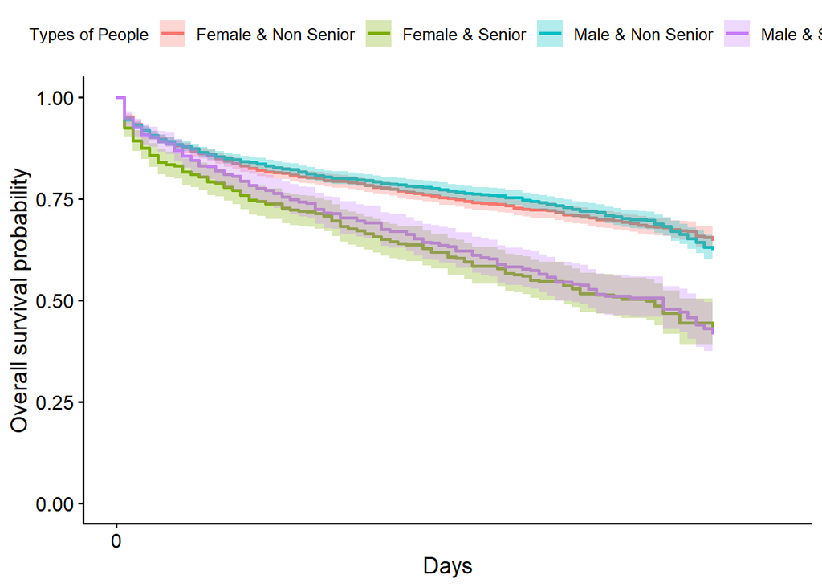

```r
library(survival)
Churn$churn1 <- 0
Churn$churn1[Churn$Churn=="Yes"]<-1
survminer::ggsurvplot(
    fit = survival::survfit(survival::Surv(tenure, churn1) ~ gender+SeniorCitizen, data = Churn),
    xlab = "Days",
    ylab = "Overall survival probability",
    legend.title = "Types of People",
    conf.int = TRUE,
    legend.labs = c("Female & Non Senior", "Female & Senior","Male & Non Senior","Male & Senior"),
    break.x.by = 100,
    censor = FALSE)
```

Answer: It appears that the Female & Non Senior and Male & Non Senior groups have higher survival probabilities over time compared to the Female & Senior and Male & Senior groups. This suggests that being a senior citizen may be associated with lower survival rates, regardless of gender.

5. Estimate a Kaplan Meier survival model that uses contract type as the explanatory variable. Do we see a difference between contract type?

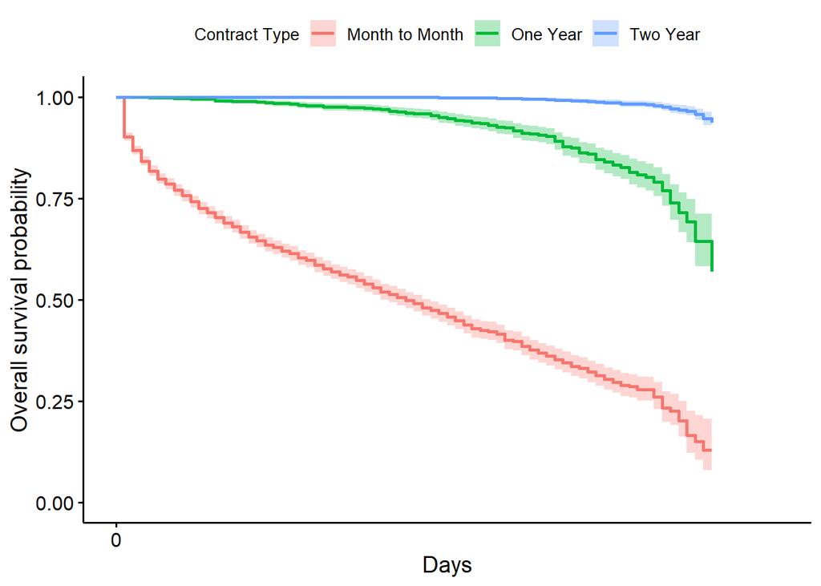

```r
Churn$churn1 <- 0
Churn$churn1[Churn$Churn=="Yes"]<-1
survminer::ggsurvplot(
    fit = survival::survfit(survival::Surv(tenure, churn1) ~ Contract, data = Churn),
    xlab = "Days",
    ylab = "Overall survival probability",
    legend.title = "Contract Type",
    conf.int = TRUE,
    legend.labs = c("Month to Month", "One Year","Two Year"),
    break.x.by = 100,
    censor = FALSE)
```

Answer: Month to Month, It shows a steep drop, signifying a high probability of churn in a shorter period. One Year, It presents a moderate fall, indicating a churn rate that is lower than Month to Month contracts but higher than Two Year contracts. Two Year: It displays the most gradual decrease, suggesting the greatest retention rate among the three contract categories. In conclusion, the chart underscores the substantial influence of contract duration on the likelihood of churn, with Two Year contracts correlating with the smallest churn rate, followed by One Year contracts, and Month to Month contracts exhibiting the highest churn rate.

6. Estimate a Cox proportional hazard model of `tenure`. Use the following variables as explanatory variables: gender, seniorcitizen, contract type, partner, dependents, type of internet access, do they have phone service, and do they use paperless billing.

```r
FIT <- survival::coxph(survival::Surv(tenure, churn1) ~ Contract + gender + SeniorCitizen + Partner + Dependents + InternetService + PhoneService + PaperlessBilling, data = Churn)

name2_fit <- broom::tidy(FIT)
colnames(name2_fit) <- c("Term", "Estimate", "Standard Error", "Statistic", "p value")
name2_fit$Term <- gsub("ContractOne year", "Contract= One year", name2_fit$Term)
name2_fit$Term <- gsub("ContractTwo year", "Contract= Two year", name2_fit$Term)
name2_fit$Term <- gsub("genderMale", "Gender= Male", name2_fit$Term)
name2_fit$Term <- gsub("SeniorCitizen", "Senior Citizen", name2_fit$Term)
name2_fit$Term <- gsub("PartnerYes", "Partner= Yes", name2_fit$Term)
name2_fit$Term <- gsub("DependentsYes", "Dependents= Yes", name2_fit$Term)
name2_fit$Term <- gsub("InternetServiceFiber optic", "Internet Service= Fiber optic", name2_fit$Term)
name2_fit$Term <- gsub("InternetServiceNo", "Internet Service= No", name2_fit$Term)
name2_fit$Term <- gsub("PhoneServiceYes", "Phone Service= Yes", name2_fit$Term)
name2_fit$Term <- gsub("PaperlessBillingYes", "Paperless Billing= Yes", name2_fit$Term)

print(name2_fit)
```

```
## # A tibble: 10 × 5
##    Term                          Estimate `Standard Error` Statistic `p value`
##    <chr>                            <dbl>            <dbl>     <dbl>     <dbl>
##  1 Contract= One year             -2.03             0.0850   -23.9   8.42e-126
##  2 Contract= Two year             -3.90             0.160    -24.4   1.36e-131
##  3 Gender= Male                   -0.0443           0.0463    -0.956 3.39e-  1
##  4 Senior Citizen                 -0.0626           0.0558    -1.12  2.62e-  1
##  5 Partner= Yes                   -0.611            0.0543   -11.3   2.25e- 29
##  6 Dependents= Yes                -0.0946           0.0681    -1.39  1.65e-  1
##  7 Internet Service= Fiber optic   0.360            0.0678     5.32  1.05e-  7
##  8 Internet Service= No           -0.225            0.112     -2.00  4.53e-  2
##  9 Phone Service= Yes             -0.123            0.0974    -1.26  2.08e-  1
## 10 Paperless Billing= Yes          0.123            0.0561     2.20  2.80e-  2
```